# Pyrmont client comparison

Onwards!

Barnabé Monnot https://twitter.com/barnabemonnot (Robust Incentives Group, Ethereum Foundation)https://github.com/ethereum/rig  
2020-11-23

## Reward rates since genesis

We first look at the reward rates per client since genesis.

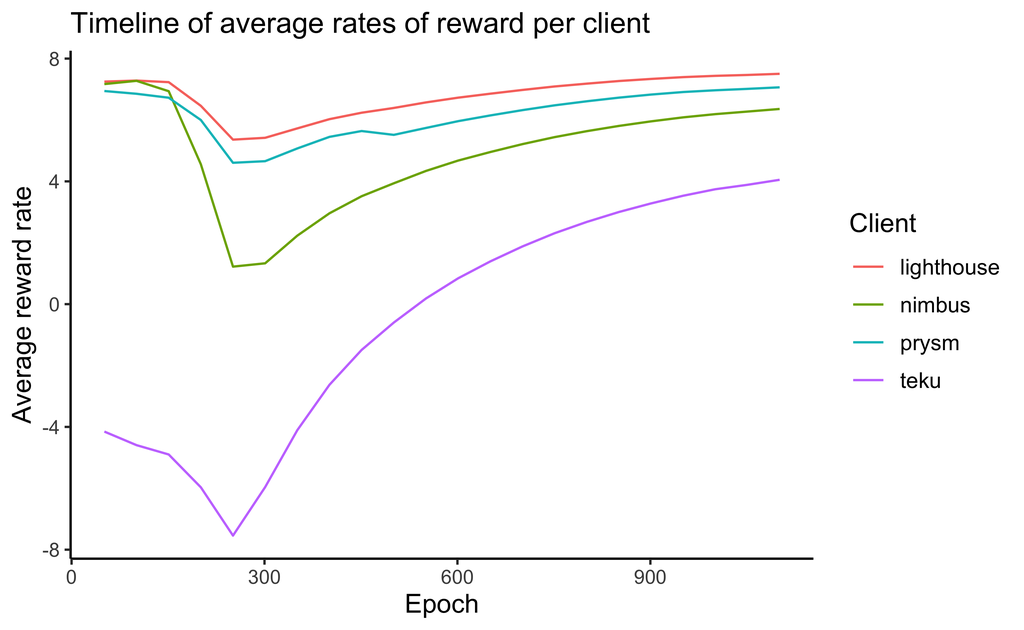

Clients are hosted on AWS nodes scattered across four regions in roughly equal proportions. We look at the reward rates per region.

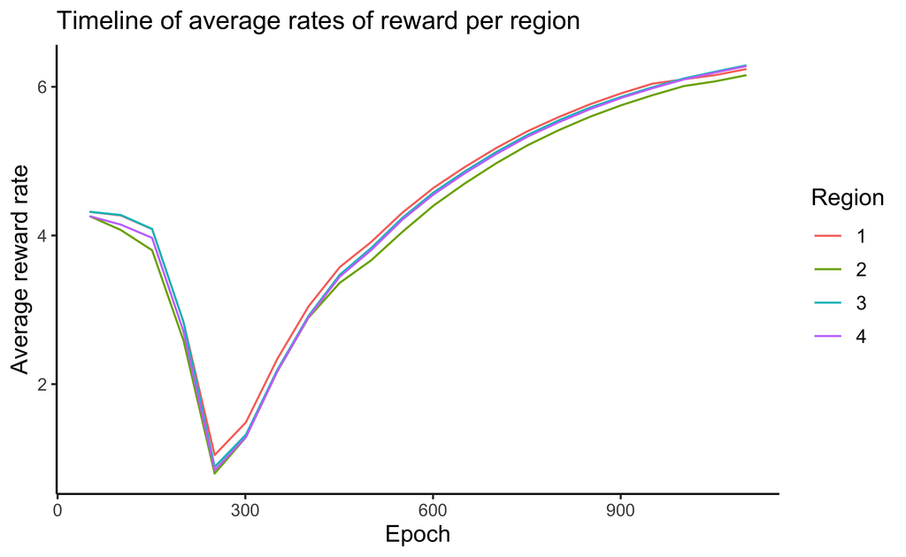

Performing an omnibus test to detect significant difference between any of the four groups, we are unable to find such significance.

## Experiment: Scaling down nodes

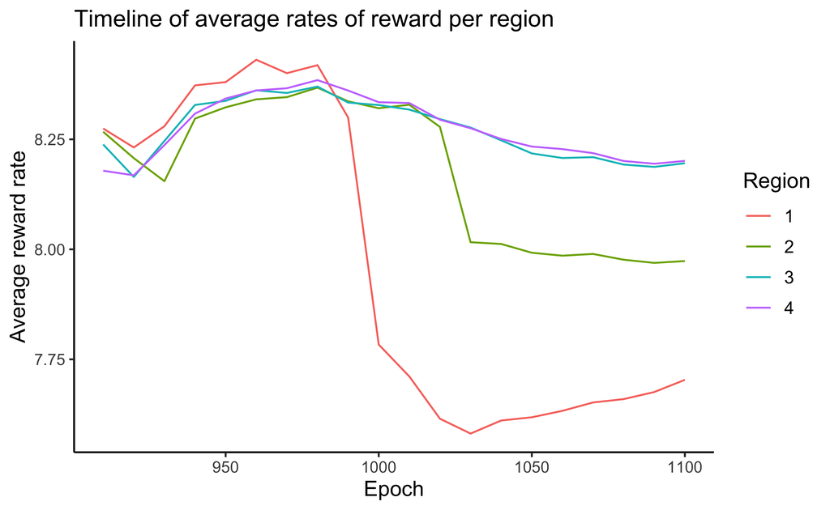

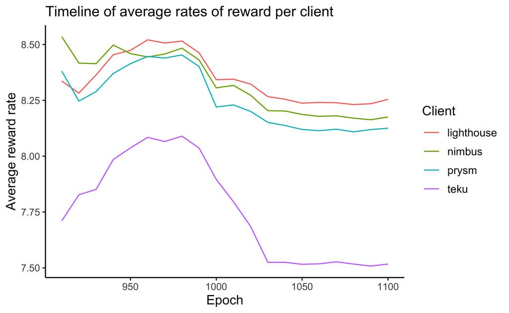

### Analysis by duty

We look at four metrics across each region:

- Percentage of included attestations.
- Percentage of correct targets among expected attestations.
- Percentage of correct heads among expected attestations.
- Average inclusion delay.

To obtain a time series, we divide the period between epoch 950 and epoch 1100 in chunks of size 10 epochs. For each validator, we record how many included attestations appear in the dataset (ranging between 0 and 10 for each chunk), the number of correct targets, correct heads and its average inclusion delay. We average over all validators in the EF-controlled set, measuring metrics either per client or per region.

We start by looking at the metrics per region.

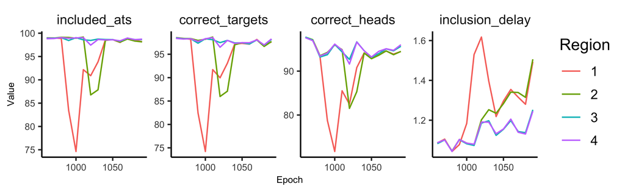

And now per client.

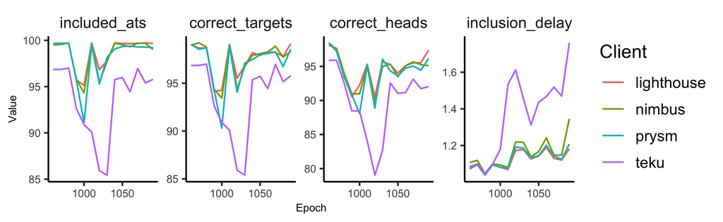